# Introduction to Computational Text Analytics

# 6 Collocation Analysis

Collocations are words that co-occur together **more often than chance**. The key idea is not just that two words appear near each other, but that they appear together *significantly more* than you would expect given how common each word is on its own.

## 6.1 Step 1: Build the Co-occurrence Matrix

```r
# we work with tokens with stopwords removed
cooee_tokens_clean <- cooee_tokens |>
  tokens_remove(stopwords("en"))

# build a feature co-occurrence matrix (FCM)
# this counts how often each pair of words appears within a window of 5 tokens
cooee_fcm <- cooee_tokens_clean |>
  fcm(
    context = "window",
    window  = 5,           # look 5 tokens either side
    tri     = FALSE        # count both directions (symmetric)
  )

# how large is the matrix?
cat("FCM dimensions:", nrow(cooee_fcm), "x", ncol(cooee_fcm), "\n")
```

```
FCM dimensions: 47503 x 47503
```

## 6.2 Step 2: Extract Collocates of a Target Word

We focus on a single target word and find its strongest collocates using Mutual Information (MI).

```r
# choose a target word
target_word <- "land"

# extract the row for the target word from the FCM
# this gives us how often every other word co-occurs with "land"
target_cooccur <- cooee_fcm[target_word, ] |>
  # convert to a tidy data frame
  as.matrix() |>
  t() |>
  as.data.frame() |>
  rownames_to_column("word") |>
  rename(cooccur_count = 2) |>
  # remove the target word itself
  filter(word != target_word, cooccur_count > 0) |>
  as_tibble()

# get total frequency of each word in the corpus (needed for MI)
word_freq <- cooee_tokens_clean |>
  dfm() |>
  featfreq() |>
  as_tibble(rownames = "word") |>
  rename(freq = value)

# get total token count (needed for MI calculation)
total_tokens <- sum(word_freq$freq)

# get frequency of target word
target_freq <- word_freq |>
  filter(word == target_word) |>
  pull(freq)

# compute association measures
collocates <- target_cooccur |>
  left_join(word_freq, by = "word") |>
  filter(!is.na(freq)) |>
  mutate(
    # Mutual Information: measures how much more often the pair co-occurs
    # than expected by chance (high MI = strong but possibly rare association)
    MI = log2(
      (cooccur_count * total_tokens) /
      (target_freq * freq)
    ),
    # t-score: favours frequent and reliable collocations
    t_score = (cooccur_count - (target_freq * freq / total_tokens)) /
              sqrt(cooccur_count)
  ) |>
  # keep only words that co-occur at least 3 times
  filter(cooccur_count >= 3) |>
  arrange(desc(MI))

# view the top collocates
cat("Top collocates of '", target_word, "' by Mutual Information:\n", sep = "")
```

```
Top collocates of 'land' by Mutual Information:
```

```r
head(collocates, 20)
```

```
# A tibble: 20 × 5
   word            cooccur_count  freq    MI t_score
   <chr>                   <dbl> <dbl> <dbl>   <dbl>
 1 diemans                     9     8  9.18    2.99
 2 diemen's                  189   184  9.05   13.7
 3 ac                          3     3  9.01    1.73
 4 v.d                         5     5  9.01    2.23
 5 vandiemans                  3     3  9.01    1.73
 6 deimans                     3     3  9.01    1.73
 7 vandemans                   4     4  9.01    2.00
 8 jobbers                     3     3  9.01    1.73
 9 dieman's                   43    44  8.98    6.54
10 van                       274   284  8.96   16.5
11 diemens                    25    27  8.90    4.99
12 buckinghamshire             3     4  8.60    1.73
13 jobbing                     3     4  8.60    1.73
14 unsold                      4     6  8.43    1.99
15 cultivable                  3     5  8.27    1.73
16 arable                      3     5  8.27    1.73
17 rulers                      6    10  8.27    2.44
18 monied                      3     5  8.27    1.73
19 unimproved                  3     5  8.27    1.73
20 motto                       4     9  7.84    1.99
```

**Why Mutual Information, not just frequency?**

A word like *“the”* might co-occur with *“land”* many times, but only because *“the”* is extremely common everywhere — it tells us nothing specific about *“land”*. MI corrects for this by comparing observed co-occurrence to what we would *expect* given each word’s overall frequency. High MI means the two words attract each other specifically.

## 6.3 Step 3: Visualise a Collocation Network

A collocation network shows which words attract each other. Nodes = words, edges = strong co-occurrence.

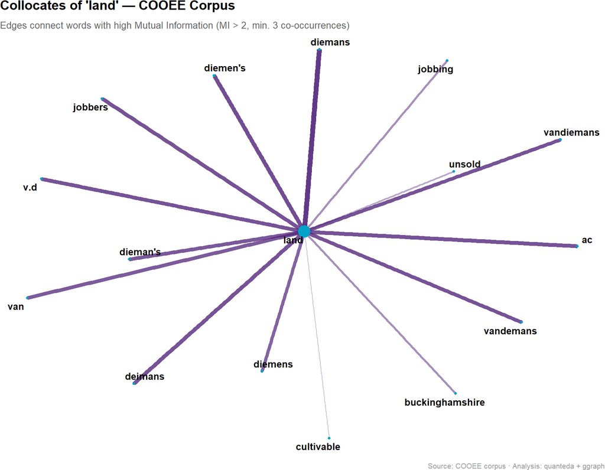

```r
# select the top collocates of our target word for the network
# we use the top 15 by MI with at least 3 co-occurrences
top_collocates <- collocates |>
  filter(MI > 2) |>
  slice_head(n = 15)

# build an edge list: target word connects to each collocate
edges <- top_collocates |>
  mutate(from = target_word) |>
  select(from, to = word, weight = MI)

# build the igraph object
collocation_graph <- graph_from_data_frame(edges, directed = FALSE)

# plot with ggraph
ggraph(collocation_graph, layout = "fr") +
  # edges: width and transparency proportional to MI strength
  geom_edge_link(
    aes(width = weight, alpha = weight),
    colour      = "#51247A",
    show.legend = FALSE
  ) +
  # nodes
  geom_node_point(
    aes(size = ifelse(name == target_word, 8, 4)),
    colour      = "#00A2C7",
    show.legend = FALSE
  ) +
  # word labels
  geom_node_text(
    aes(label = name),
    repel    = TRUE,
    size     = 3.5,
    fontface = "bold"
  ) +
  scale_edge_width(range = c(0.4, 2.5)) +
  scale_edge_alpha(range = c(0.3, 0.9)) +
  labs(
    title    = paste0("Collocates of '", target_word, "' — COOEE Corpus"),
    subtitle = "Edges connect words with high Mutual Information (MI > 2, min. 3 co-occurrences)",
    caption  = "Source: COOEE corpus · Analysis: quanteda + ggraph"
  ) +
  theme_void() +
  theme(
    plot.title    = element_text(size = 14, face = "bold", margin = margin(b = 4)),
    plot.subtitle = element_text(size = 10, color = "grey40"),
    plot.caption  = element_text(size = 8,  color = "grey60")
  )
```

## 🔧 Task 3: Explore Collocations

```r
# QUESTION 1: Look at the top 10 collocates of "land" by MI.
# What do they tell you about how "land" was discussed in these letters?

# QUESTION 2: Change the target word and re-run the analysis.
# Try: "home", "ship", "work", "wife", or "family"
target_word <- "home"   # change this

# Re-run the co-occurrence extraction and network plot above.
# How does the collocation profile of your new word differ from "land"?

# QUESTION 3: Compare MI vs t-score rankings.
# Run: head(arrange(collocates, desc(t_score)), 10)
# Which words appear in the t-score top 10 but not the MI top 10?
# Why might that be?
head(arrange(collocates, desc(t_score)), 10)
```

# 7 Keyword Analysis

Keyword analysis identifies words that are statistically *distinctive* in the COOEE corpus compared to a reference corpus (BROWN). A keyword is not simply a frequent word — it is a word that appears significantly more often than you would expect based on general English usage.

## 7.1 Load the BROWN Reference Corpus

```r
# note: BROWN files use upper-case extension .TXT
brown_files <- list.files(
  path       = here("data", "BROWN"),
  pattern    = "\\.TXT$",
  full.names = TRUE
)

brown_texts <- tibble(filepath = brown_files) |>
  mutate(
    id   = str_remove(basename(filepath), "\\.TXT$"),
    text = map_chr(filepath, \(f) read_file(f)) |>
      # extract only words (letter sequences), discard all numbers/codes/punctuation
      str_extract_all("[a-zA-Z]+") |>
      map_chr(\(words) paste(words, collapse = " "))
  ) |>
  select(id, text)  |>
  # remove sngle letters
  dplyr::mutate(text = stringr::str_remove_all(text, "\\b\\w\\b"))

cat("BROWN files loaded:", nrow(brown_texts), "\n")
```

```
BROWN files loaded: 15
```

```r
# inspect
head(brown_texts)
```

```
# A tibble: 6 × 2
  id       text
  <chr>    <chr>
1 BROWN2_A " The Fulton County Grand Jury said Friday an investigation  of Atla…
2 BROWN2_B " ASSEMBLY SESSION BROUGHT MUCH GOOD  The General Assembly which adj…
3 BROWN2_C " IT IS NOT NEWS that Nathan Milstein is  wizard  of the violin Cert…
4 BROWN2_D " As  result although we still make use of this distinction  there i…
5 BROWN2_E "  Too often  beginning bodybuilder has to do his  training secretly…
6 BROWN2_F " In American romance almost nothing rates higher  than what the mov…
```

## 7.2 Build a Combined DFM

For keyness analysis we need a **Document-Feature Matrix** with both corpora labelled. The key is to embed the `corpus_label` variable in the data *before* building the corpus, so it is available as a docvar for grouping.

```r
# combine COOEE and BROWN into one labelled tibble
combined_texts <- bind_rows(
  cooee_clean |>
    select(id, text = text_clean) |>
    mutate(corpus_label = "COOEE"),
  brown_texts |>
    mutate(corpus_label = "BROWN")
)

# build corpus from the combined tibble
combined_corpus <- corpus(
  combined_texts,
  docid_field = "id",
  text_field  = "text"
)

# assign corpus_label explicitly as a docvar
# (safest approach: pull directly from the source tibble)
docvars(combined_corpus, "corpus_label") <- combined_texts$corpus_label

# build the DFM, then group by corpus_label
# grouping collapses all COOEE documents into one row and all BROWN into one row
combined_dfm <- combined_corpus |>
  tokens(
    remove_punct   = TRUE,
    remove_numbers = TRUE,
    remove_symbols = TRUE
  ) |>
  tokens_tolower() |>
  tokens_remove(stopwords("en")) |>
  dfm() |>
  dfm_group(groups = docvars(combined_corpus, "corpus_label"))

# confirm we have exactly 2 documents (COOEE and BROWN)
combined_dfm
```

```
Document-feature matrix of: 2 documents, 67,695 features (34.36% sparse) and 1 docvar.
       features
docs    dear sir pleasure sending seeds gladly sent larger quantity person
  BROWN   56  95       63      34    42      4  145    123       33    182
  COOEE 1062 749      288     146    87     25  902    154      266    845
[ reached max_nfeat ... 67,685 more features ]
```

## 7.3 Compute Keyness

```r
# compute keyness: COOEE is the target, BROWN is the reference
# lr = log-likelihood ratio (G2) — the most robust measure
cooee_keyness <- textstat_keyness(
  combined_dfm,
  target  = "COOEE",
  measure = "lr"
)

# top 20 keywords (most distinctive in COOEE vs BROWN)
head(cooee_keyness, 20)
```

```
     feature        G2 p n_target n_reference
1     colony 1721.6601 0     2183          29
2      shall 1602.6450 0     3275         268
3         mr 1510.4290 0     5167         839
4      miles 1375.4358 0     2563         173
5     sydney  980.5288 0     1146           5
6    natives  909.7366 0     1120          11
7       upon  896.5943 0     3066         497
8    country  867.4262 0     2503         340
9      court  761.8442 0     2000         242
10     wales  718.4394 0      903          11
11      land  678.0386 0     1811         224
12      dear  627.7911 0     1062          56
13     creek  578.9620 0      805          20
14 australia  562.4824 0      725          11
15        us  527.4371 0     2920         678
16         c  515.4555 0      571           0
17     south  511.5204 0     1655         254
18  convicts  504.4879 0      612           5
19     river  478.9219 0     1307         166
20   o'clock  475.7269 0      527           0
```

## 7.4 Visualise Keywords

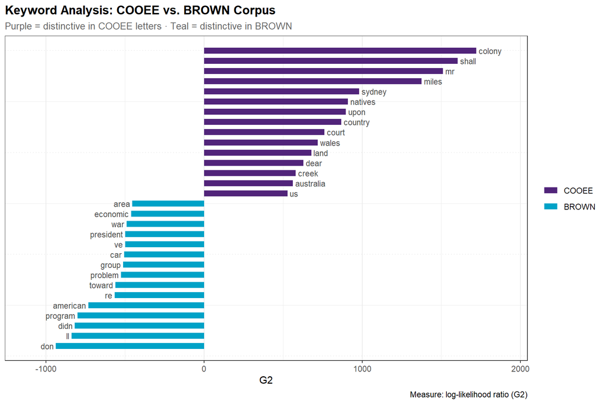

```r
# plot top 15 positive keywords (more in COOEE) and top 15 negative (more in BROWN)
textplot_keyness(
  cooee_keyness,
  n         = 15,
  color     = c("#51247A", "#00A2C7"),
  labelsize = 3
) +
  labs(
    title    = "Keyword Analysis: COOEE vs. BROWN Corpus",
    subtitle = "Purple = distinctive in COOEE letters · Teal = distinctive in BROWN",
    caption  = "Measure: log-likelihood ratio (G2)"
  ) +
  theme(
    plot.title    = element_text(face = "bold"),
    plot.subtitle = element_text(color = "grey40", size = 10)
  )
```

## 🔧 Task 4: Interpret the Keywords

```r
# QUESTION 1: Look at the top 10 keywords for COOEE.
# What topics or themes do these words suggest?
# What does this tell us about what was important to early immigrants?

# QUESTION 2: Look at the top words that are MORE common in BROWN.
# Why might these be more common in standard American English
# than in 19th-century Australian immigrant letters?

# QUESTION 3: Try a different keyness measure.
# Change measure = "lr" to measure = "chi2"
cooee_keyness_chi2 <- textstat_keyness(
  combined_dfm,
  target  = "COOEE",
  measure = "chi2"
)
head(cooee_keyness_chi2, 15)

# Compare to the log-likelihood results.
# Which words appear in both lists? Which differ?
```

## 🔧 Task 5: Diachronic Keyword Analysis

Can we detect how language changed across the three time periods in COOEE?

```r
# Build a DFM grouped by time period
cooee_period_dfm <- cooee_corpus |>
  tokens(remove_punct = TRUE, remove_numbers = TRUE) |>
  tokens_tolower() |>
  tokens_remove(stopwords("en")) |>
  dfm() |>
  dfm_group(groups = "period")

cooee_period_dfm

# YOUR TURN: compute keyness comparing Late to Early letters
late_vs_early <- textstat_keyness(
  cooee_period_dfm,
  target = "Late (1870-1900)"
)

head(late_vs_early, 15)

# Plot the results
textplot_keyness(late_vs_early, n = 20)

# REFLECTION: What words become more distinctive in later letters?
# What words characterise earlier letters?
# What historical changes might explain these differences?
```

# 8 Where to Go Next

| Method | LADAL Tutorial |
| --- | --- |
| Concordancing | [ladal.edu.au/tutorials/concordancing](https://ladal.edu.au/tutorials/concordancing/concordancing.html) |
| Collocation Analysis | [ladal.edu.au/tutorials/collocations](https://ladal.edu.au/tutorials/collocations/collocations.html) |
| Keyword Analysis | [ladal.edu.au/tutorials/keywords](https://ladal.edu.au/tutorials/keywords/keywords.html) |
| Sentiment Analysis | [ladal.edu.au/tutorials/sentiment](https://ladal.edu.au/tutorials/sentiment/sentiment.html) |
| Topic Modelling | [ladal.edu.au/tutorials/topic](https://ladal.edu.au/tutorials/topic/topic.html) |
| POS Tagging | [ladal.edu.au/tutorials/pos_tagging](https://ladal.edu.au/tutorials/pos_tagging/pos_tagging.html) |
| Network Analysis | [ladal.edu.au/tutorials/network_analysis](https://ladal.edu.au/tutorials/network_analysis/network_analysis.html) |

**Corpus Linguistics Showcase**

For a complete worked example using corpus methods on historical text (including COOEE!), see:  
[Showcase: Comparing Methods for Conceptual Maps](https://ladal.edu.au/tutorials/conceptual_maps_comparison/conceptual_maps_comparison.html)